# STAD29 Assignment 4

You are expected to complete this assignment on your own: that is, you may discuss general ideas with others, but the writeup of the work must be entirely your own. If your assignment is unreasonably similar to that of another student, you can expect to be asked to explain yourself.

If you run into problems on this assignment, it is up to you to figure out what to do. The only exception is if it is *impossible* for you to complete this assignment, for example a data file cannot be read. (There is a difference between you not knowing how to do something, which you have to figure out, and something being impossible, which you are allowed to contact me about.)

You must hand in a rendered document that shows your code, the output that the code produces, and your answers to the questions. This should be a file with `.html` on the end of its name. There is no credit for handing in your unrendered document (ending in `.qmd`), because the grader cannot then see whether the code in it runs properly. After you have handed in your file, you should be able to see (in Attempts) what file you handed in, and you should make a habit of checking that you did indeed hand in what you intended to, and that it displays as you expect.

Hint: render your document frequently, and solve any problems as they come up, rather than trying to do so at the end (when you may be close to the due date). If your document will not successfully render, it is because of an error in your code that you will have to find and fix. The error message will tell you *where* the problem is, but it is up to you to sort out *what* the problem is.

# 1 Choice-box

A psychology experiment began by showing a video in which four German children demonstrated how to use a device called a “choice-box”, which consisted of three pipes. Three of the children in the video used pipe #1, demonstrating how to throw a ball into the pipe and receive a toy from a dispenser. The other child in the video used pipe #2, also throwing a ball into the pipe and receiving a toy from the dispenser. Pipe #3 was never used on the video.

The pipes on the choice-box were actually different colours, and different versions of the video were used in which the identity of pipes #1, #2, and #3 were varied at random, and the order of children using pipes #1 and #2 on the video were also varied at random: sometimes the three children demonstrating the same pipe appeared first, and sometimes the one child demonstrating the other pipe appeared first.

The 629 subjects of the experiment, who were other children of various ages, were each given one ball to use in the choice-box. The experimenter noted which pipe each subject threw the ball into, and how it related to the pipes used in the video that subject had watched. These are in the column `y`:

- `majority`: the subject threw their ball into the pipe demonstrated by three children on their video (what I called pipe #1).
- `minority`: the subject threw their ball into the pipe demonstrated by only one child on their video (what I called pipe #2).
- `unchosen`: the subject threw their ball into the pipe demonstrated by none of the children on their video (what I called pipe #3). I should probably point out that these subjects got a toy from the dispenser as well.

The aim of the experiment was to see whether the subjects were influenced by what happened on the video they saw: for example, was a subject more likely to choose the pipe demonstrated three times on their video? The experimenters also recorded the gender, age, and culture of each subject (coded as C1 through C8), along with whether the video showed three children using pipe #1 first, or one child using pipe #2 first. Did these other variables have an effect on which pipe a subject chose? This kind of experiment might shed some light about how children are influenced by what they see and what changes it.

The data are in http://ritsokiguess.site/datafiles/Boxes.csv.

## (a) (1 point) Read in and display (some of) the data.

As ever:

```r
my_url <- "http://ritsokiguess.site/datafiles/Boxes.csv"
boxes <- read_csv(my_url)
boxes
```

| y | gender | age | culture | majority_first |
| --- | --- | --- | --- | --- |
| unchosen | girl | 6 | C2 | no |
| minority | girl | 8 | C2 | no |
| majority | boy | 8 | C2 | yes |
| unchosen | girl | 6 | C2 | no |
| majority | girl | 5 | C2 | yes |
| majority | boy | 7 | C2 | yes |
| majority | boy | 6 | C2 | no |
| unchosen | girl | 6 | C2 | yes |
| minority | girl | 8 | C2 | no |
| majority | girl | 5 | C2 | yes |

[output cut: 619 more lines]

There are 629 rows (subjects), with one per row (which will mean later that we don’t have to deal with that `weights` thing).

Extra: the culture values are?

```r
boxes %>% count(culture)
```

| culture | n |
| --- | --- |
| C1 | 94 |
| C2 | 48 |
| C3 | 215 |
| C4 | 72 |
| C5 | 67 |
| C6 | 69 |
| C7 | 24 |
| C8 | 40 |

I had to work this out to finish writing the question. There are more children from culture C3 than any other.

## (b) (2 points) What assumption is made about the response categories in order to use `multinom` from package `nnet`?

The response categories are assumed to be *unordered* (or, labels for different categories in no particular order).

You can decide for yourself whether *you* think the categories of `y` are actually ordered or unordered. For example, you might think that a sensible ordering would be majority, minority, unchosen, in descending order of how much influence the video had over the subject, but we are going to treat them as unordered here.

## (c) (2 points) Fit an appropriate model for predicting the (treated as unordered) category of `y` from the other variables. Include a squared term in `age`. You don’t need to display any results.

That means something like this:

```r
boxes.1 <- multinom(y ~ gender + age + I(age^2) + culture + majority_first,
                    data = boxes)
```

## (d) (3 points) To find out what, if anything, you can remove from your model, use `step`. The input to `step` is a model (here, the one you fitted in the previous part). The output from `step` is another model, the one obtained by removing everything that can be removed. Save this model. Running `step` displays some additional output, showing you what it is doing. (You might find that there is a lot of additional output; that is fine to hand in on this assignment.)

Aside: In most cases, `drop1` works just fine, and you can remove non-significant things one at a time. This, however, is not one of those cases:

```r
drop1(boxes.1, test = "Chisq")
```

```
trying - gender
```

```
Error in if (trace) {: argument is not interpretable as logical
```

This is, as far as I can tell, an actual bug in `multinom`, or in the way `multinom` interfaces with `drop1`, one that no-one has gotten around to fixing.

End of aside.

So what you can do is to run `step` and let *it* do the removal of unimportant explanatory variables for you:

```r
boxes.2 <- step(boxes.1)
```

```
Start:  AIC=1279.04
y ~ gender + age + I(age^2) + culture + majority_first

trying - gender
trying - age
trying - I(age^2)
trying - culture
trying - majority_first
                 Df      AIC
- culture        10 1266.575
- age            22 1278.764
- I(age^2)       22 1278.996
<none>           24 1279.041
- gender         22 1281.917
- majority_first 22 1337.572

Step:  AIC=1266.58
y ~ gender + age + I(age^2) + majority_first

trying - gender
trying - age
trying - I(age^2)
trying - majority_first
                 Df      AIC
<none>           10 1266.575
- age             8 1267.455
- I(age^2)        8 1268.186
- gender          8 1269.026
- majority_first  8 1325.546
```

At the bottom of the extra output is a table showing what is in the final model from `step`: age, age-squared, gender, and `majority_first`. The top line `<none>` says that it is best, according to AIC (which is what `step` uses) to take out nothing else.

The main reason for the long extra output, though, is that `multinom` had to be run a bunch of times:

- starting from what I called `boxes.1`, take out each of the explanatory variables from the model one at a time and fit the model without each one, saving the AIC from each fit
- make a table showing the resulting AIC for the removal of each explanatory variable, including removing nothing
- remove the best thing to remove (here `culture`)
- repeat the first two steps for the current best model
- the best thing to remove is now nothing, so we are done, and the table shows what is still in our model.

## (e) (3 points) For your best model, create a dataframe for predicting the probability that a child will choose the majority, minority, or unchosen pipe, for ages 5 through 13. What values have been used for the other explanatory variables?

This means using `datagrid` to supply some representative values for the other variables, and the ages we want. Use the model that came out of `step`, which I called `boxes.2`:

```r
new <- datagrid(model = boxes.2, age = c(5:13))
new
```

| y | gender | majority_first | age |
| --- | --- | --- | --- |
| majority | boy | no | 5 |
| majority | boy | no | 6 |
| majority | boy | no | 7 |
| majority | boy | no | 8 |
| majority | boy | no | 9 |
| majority | boy | no | 10 |
| majority | boy | no | 11 |
| majority | boy | no | 12 |
| majority | boy | no | 13 |

As per tradition, my resulting dataframe is called `new`.

Two points for that much. The other point is for saying what values of the other variables found their way into your dataframe and why. These are gender `boy` and `majority_first` being `no` (and `y` being `majority`, but this is not used in the predictions). These are categorical, and these categories appear here because they are the most frequent categories in the data.

Extra: you don’t need to demonstrate that your assertion is correct, but if you wanted to:

```r
boxes %>% count(gender)
```

| gender | n |
| --- | --- |
| boy | 318 |
| girl | 311 |

```r
boxes %>% count(majority_first)
```

| majority_first | n |
| --- | --- |
| no | 324 |
| yes | 305 |

It is a close call, but there are a few more boys than girls in the dataset, and slightly more of the time, what I called pipe #2 was demonstrated first in the video that a subject saw.[^1]

## (f) (3 points) Calculate and display your predictions side by side with the corresponding explanatory variable values. Arrange your predictions in a way that makes them easier to compare.

`predictions`. Select the output columns you want to keep, and then pivot the `group` (predicted response category) wider:

```r
cbind(predictions(boxes.2, newdata = new)) %>%
  select(group, age, gender, majority_first, estimate) %>%
  pivot_wider(names_from = group, values_from = estimate)
```

| age | gender | majority_first | majority | minority | unchosen |
| --- | --- | --- | --- | --- | --- |
| 5 | boy | no | 0.3855886 | 0.4402763 | 0.1741350 |
| 6 | boy | no | 0.3471692 | 0.4694634 | 0.1833674 |
| 7 | boy | no | 0.3242921 | 0.4825467 | 0.1931612 |
| 8 | boy | no | 0.3155529 | 0.4800656 | 0.2043815 |
| 9 | boy | no | 0.3200679 | 0.4625714 | 0.2173607 |
| 10 | boy | no | 0.3375846 | 0.4306363 | 0.2317792 |
| 11 | boy | no | 0.3682588 | 0.3852613 | 0.2464798 |
| 12 | boy | no | 0.4121456 | 0.3285565 | 0.2592978 |
| 13 | boy | no | 0.4684612 | 0.2644072 | 0.2671316 |

Two points for the first two lines, and a third point for doing some sensible rearrangement of the predictions to make them easier to read.

Extra: the effect of age is that the youngest and oldest children are most likely to follow the majority (what I called pipe #1); older children are less likely to follow the minority (vs younger children) and more likely to choose the pipe that was never chosen on their video. Come up with your own explanation of why you think that is.

(The age effect for girls is the same as for boys, at least according to our model, because there is no interaction between gender and age in the model. I tried adding one, but it was not significant, so the effect of age seems to be the same for boys and for girls.)

## (g) (2 points) Plot the predictions as they depend on age. Hint: use the simplified procedure shown in lecture, not the complicated one shown in the lecture notes.

Probably the easiest way to think about this is to start with what comes out of `predictions` before you tidy it up:

```r
cbind(predictions(boxes.2, newdata = new))
```

| rowid | group | estimate | std.error | statistic | p.value | s.value | conf.low | conf.high | y | gender | majority_first | age |
| --- | --- | --- | --- | --- | --- | --- | --- | --- | --- | --- | --- | --- |
| 1 | majority | 0.3855886 | 0.04580965 | 8.417192 | 3.856141e-17 | 54.52562 | 0.2958034 | 0.4753739 | majority | boy | no | 5 |
| 2 | majority | 0.3471692 | 0.03669722 | 9.460369 | 3.068596e-21 | 68.14291 | 0.2752440 | 0.4190944 | majority | boy | no | 6 |
| 3 | majority | 0.3242921 | 0.03547355 | 9.141800 | 6.142127e-20 | 63.81982 | 0.2547652 | 0.3938190 | majority | boy | no | 7 |
| 4 | majority | 0.3155529 | 0.03650987 | 8.642947 | 5.478130e-18 | 57.34102 | 0.2439949 | 0.3871110 | majority | boy | no | 8 |
| 5 | majority | 0.3200679 | 0.03714477 | 8.616770 | 6.886948e-18 | 57.01084 | 0.2472655 | 0.3928703 | majority | boy | no | 9 |
| 6 | majority | 0.3375846 | 0.03755765 | 8.988437 | 2.507717e-19 | 61.79026 | 0.2639729 | 0.4111962 | majority | boy | no | 10 |
| 7 | majority | 0.3682588 | 0.04050708 | 9.091223 | 9.793163e-20 | 63.14679 | 0.2888664 | 0.4476512 | majority | boy | no | 11 |
| 8 | majority | 0.4121456 | 0.05072833 | 8.124565 | 4.489708e-16 | 50.98423 | 0.3127199 | 0.5115713 | majority | boy | no | 12 |
| 9 | majority | 0.4684612 | 0.07104509 | 6.593858 | 4.285405e-11 | 34.44178 | 0.3292154 | 0.6077071 | majority | boy | no | 13 |
| 1 | minority | 0.4402763 | 0.04870001 | 9.040579 | 1.558444e-19 | 62.47653 | 0.3448260 | 0.5357266 | majority | boy | no | 5 |

[output cut: 17 more lines]

The category of `y` being predicted for is called `group` (then, as you recall, we took the `estimate` for each `group` and pivoted them wider to make them easier to look at).

Then think back to what we did when plotting the predictions for the coal miners: we put the `group` on the end of the `condition`. In this case, that means having `age` first and then `group`:

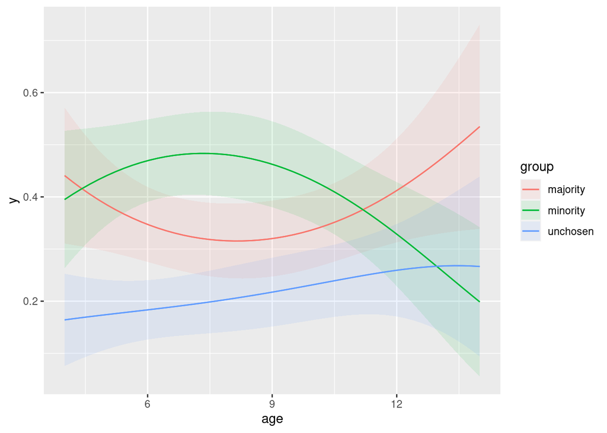

```r
plot_predictions(model = boxes.2, condition = c("age", "group"))
```

It is perfectly good (though more, unnecessary, work for you) to grapple with what is in the lecture notes:

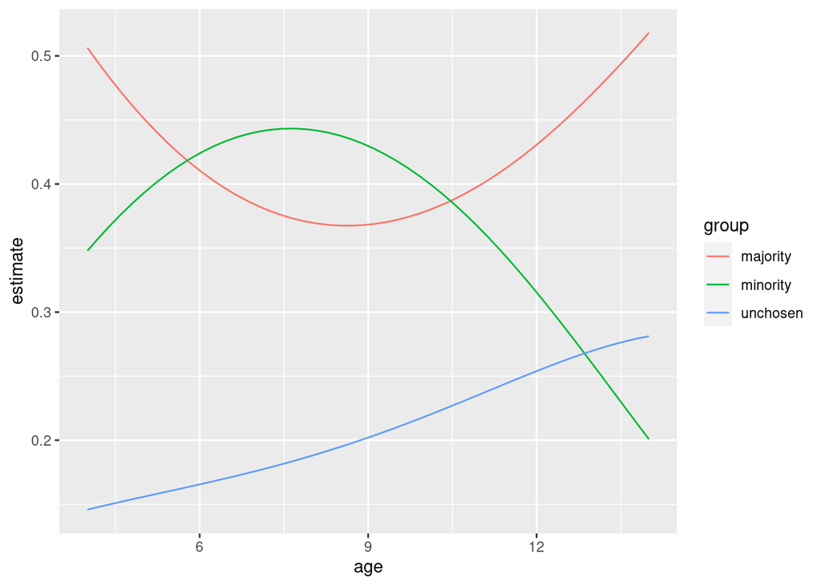

```r
plot_predictions(boxes.1, condition = c("age"), type = "probs", draw = FALSE)  %>%
  ggplot(aes(x = age, y = estimate, colour = group)) +
  geom_line()
```

Extra: You might be wondering what values are being used for the other variables `gender` and `majority_first` in the graph. I think it is the same as for `datagrid`: the most common category. I haven’t checked this; one way you might investigate is to compare the predictions you got in the previous part with your graph here.

The way `plot_predictions` works is to put the first thing in `condition` on the $x$-axis, to use coloured curves for the second thing, and to use facets for the third thing (if there is one). This suggests that you might add gender to the plot like this:

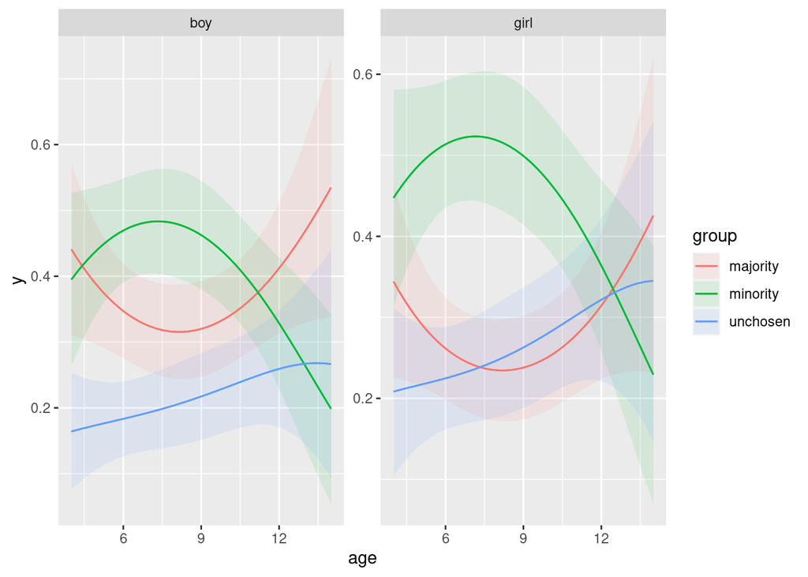

```r
plot_predictions(model = boxes.2, condition = c("age", "group", "gender"))
```

It seems to make sense to keep the colours to represent the outcome category.

What we see here is that regardless of age, girls are more likely than boys to go with the minority (pipe #2) on their video, and less likely to go with the majority (pipe #1).

It also looks as if the plot I had you make was indeed based on boys.

# 2 NBA schedule

The NBA (National Basketball Association) runs North America’s major basketball league, whose games are played from October to April. The 2023-2024 schedule is at http://ritsokiguess.site/datafiles/nba_sched.csv.

## (a) (1 point) Read in and display some of the data.

As you well know by now:

```r
my_url <- "http://ritsokiguess.site/datafiles/nba_sched.csv"
nba <- read_csv(my_url)
nba
```

| date | road | home | start_eastern | TV |
| --- | --- | --- | --- | --- |
| 10/24/23 | L.A. Lakers | Denver | 7:30 PM | TNT |
| 10/24/23 | Phoenix | Golden State | 10:00 PM | TNT |
| 10/25/23 | Atlanta | Charlotte | 7:00 PM | NA |
| 10/25/23 | Washington | Indiana | 7:00 PM | NA |
| 10/25/23 | Boston | New York | 7:00 PM | ESPN |
| 10/25/23 | Houston | Orlando | 7:00 PM | NA |
| 10/25/23 | Cleveland | Brooklyn | 7:30 PM | NA |
| 10/25/23 | Detroit | Miami | 7:30 PM | NA |
| 10/25/23 | Minnesota | Toronto | 7:30 PM | NA |
| 10/25/23 | Oklahoma City | Chicago | 8:00 PM | NA |

[output cut: 1190 more lines]

Extra: there is (as you might guess) a story to tell here. I went searching for the season schedule, and most of what you can find is something like the current week’s games (on, for example, a TV network website). The schedule you just read in is based on what looks like a press release from the NBA directly with the entire season’s schedule in it, but it was a PDF, and I didn’t know how to extract things from a PDF in R. Until I found out, that is. Most of what I do here uses ideas at https://crimebythenumbers.com/scrape-table.html.

There is a package `pdftools` that will help you extract text from PDF files, such as the one with the schedule in it [here](https://ak-static.cms.nba.com/wp-content/uploads/sites/46/2023/08/2023-24-NBA-Schedule-By-Date-as-of-8-17-23.pdf).

So:

```r
library(pdftools)
```

as well as the usual `library(tidyverse)`, and then:

```r
my_url <- "https://ak-static.cms.nba.com/wp-content/uploads/sites/46/2023/08/2023-24-NBA-Schedule-By-Date-as-of-8-17-23.pdf"
nba_pdf <- pdf_text(my_url)
str(nba_pdf)
```

```
 chr [1:24] "2023-24 NBA REGULAR SEASON SCHEDULE\nAS OF AUGUST 17, 2023 | SUBJECT TO CHANGE\n\n\n DAY      DATE         AWAY"| __truncated__ ...
```

`pdf_text`, from `pdftools`, extracts the text from a pdf file. Not in a very convenient way, though. There were 24 pages in the original, and the last line above (which shows the “structure”[^2] of `nba_pdf` without displaying all of it, because it is long) shows that each one of the pages ended up as one element of a text vector.

Let’s take a look at the last page (which is the shortest). This is one very long line, so scroll right to see more. Square brackets for pulling things out of a vector:

```r
nba_pdf[24]
```

```
[1] "                         2023-24 NBA REGULAR SEASON SCHEDULE\n\n          DAY        DATE            AWAY                HOME        LOCAL       ET       NAT TV   #\n          Sun.      4/14/24           Detroit         San Antonio     2:30 PM   3:30 PM\n          Sun.      4/14/24            U…
```

What you can do now is to compare this to the last page of the original pdf. It contains all the same text, but not formatted as nicely. In particular, everywhere you see a `\n` in the above is the start of a new line in the original.[^3] So a good first step would be to turn those newline symbols into real newlines, which you can do like this:

```r
nba_strings <- strsplit(nba_pdf, split = "\n")
str(nba_strings)
```

```
List of 24
 $ : chr [1:53] "2023-24 NBA REGULAR SEASON SCHEDULE" "AS OF AUGUST 17, 2023 | SUBJECT TO CHANGE" "" "" ...
 $ : chr [1:57] "                         2023-24 NBA REGULAR SEASON SCHEDULE" "" "          DAY        DATE        AWAY              HOME        LOCAL       ET       NAT TV   #" "          Mon.      10/30/23      Detroit      Oklahoma City   7:00 PM    8:00 PM" ...
 $ : chr [1:58] "                         2023-24 NBA REGULAR SEASON SCHEDULE" "" "          DAY        DATE         AWAY              HOME        LOCAL        ET       NAT TV   #" "          Mon.       11/6/23       Atlanta      Oklahoma City    7:00 PM    8:00 PM" ...
 $ : chr [1:58] "                         2023-24 NBA REGULAR SEASON SCHEDULE" "" "          DAY        DATE         AWAY              HOME        LOCAL       ET       NAT TV   #" "          Tue.      11/14/23    LA Clippers        Denver       8:00 PM   10:00 PM    TNT     I" ...
 $ : chr [1:58] "                         2023-24 NBA REGULAR SEASON SCHEDULE" "" "          DAY        DATE         AWAY              HOME        LOCAL       ET       NAT TV   #" "          Wed.      11/22/23      Denver           Orlando      7:00 PM    7:00 PM" ...
 $ : chr [1:57] "                         2023-24 NBA REGULAR SEASON SCHEDULE" "" "          DAY        DATE         AWAY              HOME        LOCAL       ET       NAT TV   #" "          Wed.      11/29/23        Utah          Memphis       7:00 PM    8:00 PM" ...
 $ : chr [1:57] "                         2023-24 NBA REGULAR SEASON SCHEDULE" "" "          DAY        DATE         AWAY              HOME        LOCAL       ET       NAT TV   #" "          Wed.      12/13/23      Atlanta          Toronto      7:30 PM    7:30 PM" ...
 $ : chr [1:57] "                         2023-24 NBA REGULAR SEASON SCHEDULE" "" "          DAY        DATE        AWAY              HOME        LOCAL        ET     NAT TV     #" "          Wed.      12/20/23    Charlotte         Indiana       7:00 PM    7:00 PM" ...
 $ : chr [1:57] "                         2023-24 NBA REGULAR SEASON SCHEDULE" "" "          DAY        DATE         AWAY              HOME        LOCAL       ET       NAT TV   #" "          Wed.      12/27/23     Milwaukee         Brooklyn     7:30 PM    7:30 PM" ...
 $ : chr [1:57] "                        2023-24 NBA REGULAR SEASON SCHEDULE" "" "          DAY       DATE         AWAY              HOME        LOCAL       ET       NAT TV   #" "          Wed.       1/3/24      Brooklyn         Houston      7:00 PM    8:00 PM" ...
 $ : chr [1:57] "                        2023-24 NBA REGULAR SEASON SCHEDULE" "" "          DAY       DATE         AWAY              HOME         LOCAL       ET       NAT TV   #" "          Wed.      1/10/24    Philadelphia         Atlanta     7:30 PM    7:30 PM   ESPN" ...
 $ : chr [1:57] "                        2023-24 NBA REGULAR SEASON SCHEDULE" "" "          DAY       DATE         AWAY              HOME         LOCAL        ET       NAT TV   #" "          Wed.      1/17/24      Houston          New York       7:30 PM    7:30 PM" ...
 $ : chr [1:57] "                        2023-24 NBA REGULAR SEASON SCHEDULE" "" "          DAY       DATE         AWAY              HOME         LOCAL        ET       NAT TV   #" "          Wed.      1/24/24      Phoenix            Dallas       9:00 PM   10:00 PM   ESPN" ...
 $ : chr [1:57] "                        2023-24 NBA REGULAR SEASON SCHEDULE" "" "          DAY       DATE         AWAY              HOME         LOCAL       ET       NAT TV   #" "          Wed.      1/31/24      Phoenix          Brooklyn      7:30 PM    7:30 PM   ESPN" ...
 $ : chr [1:57] "                        2023-24 NBA REGULAR SEASON SCHEDULE" "" "          DAY       DATE         AWAY              HOME         LOCAL        ET       NAT TV   #" "          Wed.       2/7/24      Atlanta            Boston       7:30 PM    7:30 PM   ESPN" ...
```

[output cut: 9 more lines]

`strsplit` comes from base R (so is old). There is undoubtedly something in `stringr` (beginning with `str_`) that will do the same job, but this works and is clear enough: “take the text in `nba_pdf` and turn it into a new piece of text, splitting at newlines”.

This is actually now a `list`, with one element for each page.[^4] Within the list, there is a text vector with one element for each line on that page. Each page has about 57 lines of text on it.

I don’t care which page anything is on, so I can use `unlist` to remove the “list attribute” (whatever makes it into a list), which turns it into a vector with one element per line. There is also some whitespace (spaces, tabs) at the beginning of each line, and things will work better later if I get rid of that. This does actually work with pipes, even though we are not working with dataframes:

```r
nba_strings %>%
  unlist() %>%
  trimws(which = "left") -> nba1
str(nba1)
```

```
 chr [1:1329] "2023-24 NBA REGULAR SEASON SCHEDULE" ...
```

The non-pipe equivalent has nested brackets, which I’m not a fan of:

```r
nba1 <- trimws(unlist(nba_strings), which = "left")
```

Either way, there are now 1329 lines, with no indication of pages.

I’m not a fan of nested brackets, but: turn `nba_strings` into a vector (from a list), and then remove any whitespace at the beginning (left side) of each line.

This now looks a lot better:[^5]

```r
head(nba1, 10)
```

```
 [1] "2023-24 NBA REGULAR SEASON SCHEDULE"
 [2] "AS OF AUGUST 17, 2023 | SUBJECT TO CHANGE"
 [3] ""
 [4] ""
 [5] "DAY      DATE         AWAY            HOME         LOCAL       ET       NAT TV   #"
 [6] "Tue.    10/24/23    L.A. Lakers       Denver       5:30 PM    7:30 PM    TNT"
 [7] "Tue.    10/24/23      Phoenix      Golden State    7:00 PM   10:00 PM    TNT"
 [8] "Wed.    10/25/23      Atlanta        Charlotte     7:00 PM    7:00 PM"
 [9] "Wed.    10/25/23    Washington        Indiana      7:00 PM    7:00 PM"
[10] "Wed.    10/25/23      Boston         New York      7:00 PM    7:00 PM   ESPN"
```

If this were a datafile, you could edit out the header lines and read it in with `read_table`, because the columns that interest us are aligned. I did actually think about doing it that way, but we can do better, without any hand-editing needed.

The columns in here are separated by *two or more spaces* (and a variable number of spaces at that), as you can check. We have to be a little careful, because if you pretended that the columns were separated by *one or more* spaces, you would get messed up by team names that were more than one word, like the LA Lakers or Golden State (this was where `read_table` got tripped up for me).

The `stringr` package[^6] has a function `str_split_fixed` that does exactly what we want. The inputs are:

- a vector of text to be split up (our `nba1`)
- a regular expression that says how to split it up
- the maximum number of columns to split it up into.

The regular expression below is how you encode “two or more spaces”. The first character inside the quotes is one space. The curly-bracket stuff says to match any number of that first character from 2 up to infinity. (You would expect to see another number after the comma, which would be the maximum number of spaces to match, but the fact that there isn’t one means that the number of spaces you match can be as big as you like.)

There are actually up to 8 columns, including the last one labelled `#` (I don’t know what that represents). The result is big, so I am using `str` again to show its structure:

```r
str(str_split_fixed(nba1, " {2,}", 8))
```

```
 chr [1:1329, 1:8] "2023-24 NBA REGULAR SEASON SCHEDULE" ...
```

This is actually a `matrix` now (an array with rows and columns: 1329 rows and the 8 columns we just made). You can think of `str_split_fixed` as “adding a dimension”: we had a one-dimensional vector of text, and now we have a two-dimensional matrix of text, because we split each original piece of text into 8 parts.

I don’t like dealing with matrices much, but `as_tibble` will turn anything that looks like a dataframe into an actual dataframe:

```r
str_split_fixed(nba1, " {2,}", 8) %>% as_tibble() -> nba2
```

```
Warning: The `x` argument of `as_tibble.matrix()` must have unique column names if
`.name_repair` is omitted as of tibble 2.0.0.
ℹ Using compatibility `.name_repair`.
```

```r
nba2
```

| V1 | V2 | V3 | V4 | V5 | V6 | V7 | V8 |
| --- | --- | --- | --- | --- | --- | --- | --- |
| 2023-24 NBA REGULAR SEASON SCHEDULE |  |  |  |  |  |  |  |
| AS OF AUGUST 17, 2023 \| SUBJECT TO CHANGE |  |  |  |  |  |  |  |
| DAY | DATE | AWAY | HOME | LOCAL | ET | NAT TV | # |
| Tue. | 10/24/23 | L.A. Lakers | Denver | 5:30 PM | 7:30 PM | TNT |  |
| Tue. | 10/24/23 | Phoenix | Golden State | 7:00 PM | 10:00 PM | TNT |  |
| Wed. | 10/25/23 | Atlanta | Charlotte | 7:00 PM | 7:00 PM |  |  |
| Wed. | 10/25/23 | Washington | Indiana | 7:00 PM | 7:00 PM |  |  |
| Wed. | 10/25/23 | Boston | New York | 7:00 PM | 7:00 PM | ESPN |  |

[output cut: 1319 more lines]

You can see that some of the rows of this dataframe represent actual scheduled basketball games, but some of them don’t: the others are the header and footer lines that came from the pages of the original pdf. We need some way to decide between these two kinds of rows. I first saw that the actual games have a date that ends in either `/23` or `/24`; you might also look across to `V5` or `V6` and see that the start times of actual games have an AM or a PM in them (or maybe it would be enough to match the `:` there). Anyway, the date thing is what I saw.

`stringr` has a function `str_detect` that returns `TRUE` if the first input matches the second one. The first input needs to be a piece of text, and the second one needs to be a regular expression (again!). This one says that `V2` has to match a literal slash, followed by a 2, followed by either a 3 or a 4, followed by the end of the text. (The season spans two calendar years, so a game can be played in either 2023 or 2024.)

```r
nba2 %>%
  filter(str_detect(V2, "/2[34]$")) %>%
  rename(dow = V1,
         date = V2,
         road = V3,
         home = V4,
         start_eastern = V6,
         TV = V7) %>%
  select(-dow, -V5, -V8) -> nba3
nba3
```

| date | road | home | start_eastern | TV |
| --- | --- | --- | --- | --- |
| 10/24/23 | L.A. Lakers | Denver | 7:30 PM | TNT |
| 10/24/23 | Phoenix | Golden State | 10:00 PM | TNT |
| 10/25/23 | Atlanta | Charlotte | 7:00 PM |  |
| 10/25/23 | Washington | Indiana | 7:00 PM |  |
| 10/25/23 | Boston | New York | 7:00 PM | ESPN |
| 10/25/23 | Houston | Orlando | 7:00 PM |  |
| 10/25/23 | Cleveland | Brooklyn | 7:30 PM |  |
| 10/25/23 | Detroit | Miami | 7:30 PM |  |
| 10/25/23 | Minnesota | Toronto | 7:30 PM |  |
| 10/25/23 | Oklahoma City | Chicago | 8:00 PM |  |

[output cut: 1190 more lines]

Having picked out the rows with games in them, I finally pick out the columns I want to save for you, and give them good names. I could probably do something more elegant than this using the column names that were in the original pdf, but this was enough for me. The pdf included the day of the week for each game, but I wanted you to work those out from the date, so I left them out.

Then I saved `nba3` as a csv for you.

## (b) (4 points) NBA games are played on different days of the week. Which day of the week has the most games, and which day of the week has the fewest? Use the tools you saw in lecture, in this course and STAC32, to work this out. (Hint: does it seem to matter that the year only has two digits here?)

Before you start coding, do some thinking:

- to get the days of the week, you can use `wday`.
- to use `wday`, you need actual dates, so you have to make those first. These are American-style dates, with the month first, so we will need `mdy` for this.
- once you have worked out the day of week of each game, you can use `count` to count them up, and `arrange` to put them in order.

That leads to something like this:

```r
nba %>%
  mutate(date1 = mdy(date)) %>%
  mutate(dow = wday(date1, label = TRUE)) %>%
  count(dow) %>%
  arrange(desc(n))
```

| dow | n |
| --- | --- |
| Wed | 223 |
| Fri | 214 |
| Mon | 171 |
| Sun | 165 |
| Sat | 158 |
| Tue | 142 |
| Thu | 127 |

Wednesday is the most common day for a game, and Thursday is the least common.

Points: two for making dates, one for extracting the day of the week, and one for counting them up and sorting them (or otherwise making clear which was the largest and which was the smallest count).

To pick up on the hint: let’s run the first mutate again:

```r
nba %>%
  mutate(date1 = mdy(date)) %>%
  select(date, date1)
```

| date | date1 |
| --- | --- |
| 10/24/23 | 2023-10-24 |
| 10/24/23 | 2023-10-24 |
| 10/25/23 | 2023-10-25 |
| 10/25/23 | 2023-10-25 |
| 10/25/23 | 2023-10-25 |
| 10/25/23 | 2023-10-25 |
| 10/25/23 | 2023-10-25 |
| 10/25/23 | 2023-10-25 |
| 10/25/23 | 2023-10-25 |
| 10/25/23 | 2023-10-25 |

[output cut: 1190 more lines]

`mdy` inferred that the dates were in the 21st century, so that the two-digit years were actually all right. (It would be smart to check this before you get too far into the question.)

Extra: I was actually surprised by the Wednesday thing; I was expecting a weekend day to be most common. I used to follow the NHL (back in the days of Wayne Gretzky as a player, which shows you how old I am). As I remember, there were most games on a Saturday, and fewest on a Monday, and that was the sort of thing I was expecting to see here. My guess is that a lot of people who follow the NBA also follow college basketball, many of whose games are played on Saturdays.

## (c) (4 points) You have a friend who lives in Auckland, New Zealand, who is a big basketball fan. They have a streaming package that enables them to watch any NBA game live. They get home from work at 4:00pm (local time) every day. What are some games they would be able to watch from start to finish as they happen? Use tools we have seen in lecture to find this out. For the purposes of this question, you can include games that have already been played (ie. in 2023). Hints below:

- your friend needs to know about games that start at 4:00pm or later Auckland time (16:00 or later).
- you can use `unite` to glue a date and time together as text
- if your time does not have seconds, omit the `s` in the appropriate function
- when you create a date-time that needs to be in a certain timezone, add the timezone when you create it
- `America/Toronto` will do for Eastern time; use `OlsonNames()` to get a list of all the time zone names that R knows about. (The output from `OlsonNames()` is long, so do not hand it in; just find what you need and use that.)

Again, thinking first:

- we are talking time zones, so we need actual date-times with timezones.
- the `unite` hint above says how to make a date-time as text
- use something like `ymd_hms` to make an actual date-time. Here, the months are first and the years last, and there are no seconds, so use `mdy_hm` instead. (All these permutations exist.)
- add a timezone when you are creating the date-times (Eastern time), otherwise you’ll get the UTC timezone.
- find out using `OlsonNames()` that the time zone that Auckland, NZ is in is called `Pacific/Auckland` (down near the bottom; there is also a timezone called simply `NZ` that should also work. New Zealand as a whole has only one timezone.)
- use `with_tz` to move a date-time from one timezone to another.

I know the start of a basketball game as “tip” or “tip-off”, hence my names for the columns below. Something like this is what you need:

```r
nba %>% unite(tip_text, date, start_eastern) %>%
  mutate(tip = mdy_hm(tip_text, tz = "America/Toronto")) %>%
  mutate(tip_nz = with_tz(tip, "Pacific/Auckland"))
```

| tip_text | road | home | TV | tip | tip_nz |
| --- | --- | --- | --- | --- | --- |
| 10/24/23_7:30 PM | L.A. Lakers | Denver | TNT | 2023-10-24 19:30:00 | 2023-10-25 12:30:00 |
| 10/24/23_10:00 PM | Phoenix | Golden State | TNT | 2023-10-24 22:00:00 | 2023-10-25 15:00:00 |
| 10/25/23_7:00 PM | Atlanta | Charlotte | NA | 2023-10-25 19:00:00 | 2023-10-26 12:00:00 |
| 10/25/23_7:00 PM | Washington | Indiana | NA | 2023-10-25 19:00:00 | 2023-10-26 12:00:00 |
| 10/25/23_7:00 PM | Boston | New York | ESPN | 2023-10-25 19:00:00 | 2023-10-26 12:00:00 |
| 10/25/23_7:00 PM | Houston | Orlando | NA | 2023-10-25 19:00:00 | 2023-10-26 12:00:00 |
| 10/25/23_7:30 PM | Cleveland | Brooklyn | NA | 2023-10-25 19:30:00 | 2023-10-26 12:30:00 |
| 10/25/23_7:30 PM | Detroit | Miami | NA | 2023-10-25 19:30:00 | 2023-10-26 12:30:00 |
| 10/25/23_7:30 PM | Minnesota | Toronto | NA | 2023-10-25 19:30:00 | 2023-10-26 12:30:00 |
| 10/25/23_8:00 PM | Oklahoma City | Chicago | NA | 2023-10-25 20:00:00 | 2023-10-26 13:00:00 |

[output cut: 1190 more lines]

Two points for making Eastern timezone date-times (the first two lines above); one point for getting the same date-times in Auckland time (the third line); the last point for somehow finding out which games your friend can watch (see below).

On that last point, you could scroll down and find some games that start at or after 16:00 in the `tip_nz` column. But we can do better than that: pull out the hour from `tip_nz`, and grab the ones that are 16 or more:

```r
nba %>% unite(tip_text, date, start_eastern) %>%
  mutate(tip = mdy_hm(tip_text, tz = "America/Toronto")) %>%
  mutate(tip_nz = with_tz(tip, "Pacific/Auckland")) %>%
  mutate(tip_nz_hour = hour(tip_nz)) %>%
  filter(tip_nz_hour >= 16)
```

| tip_text | road | home | TV | tip | tip_nz | tip_nz_hour |
| --- | --- | --- | --- | --- | --- | --- |
| 11/8/23_10:00 PM | Golden State | Denver | ESPN | 2023-11-08 22:00:00 | 2023-11-09 16:00:00 | 16 |
| 11/8/23_10:00 PM | Portland | Sacramento | NA | 2023-11-08 22:00:00 | 2023-11-09 16:00:00 | 16 |
| 11/10/23_10:00 PM | L.A. Lakers | Phoenix | ESPN | 2023-11-10 22:00:00 | 2023-11-11 16:00:00 | 16 |
| 11/10/23_10:00 PM | Oklahoma City | Sacramento | I | 2023-11-10 22:00:00 | 2023-11-11 16:00:00 | 16 |
| 11/12/23_10:00 PM | Portland | L.A. Lakers | NA | 2023-11-12 22:00:00 | 2023-11-13 16:00:00 | 16 |
| 11/13/23_10:00 PM | Cleveland | Sacramento | NBA TV | 2023-11-13 22:00:00 | 2023-11-14 16:00:00 | 16 |
| 11/14/23_10:00 PM | LA Clippers | Denver | TNT | 2023-11-14 22:00:00 | 2023-11-15 16:00:00 | 16 |
| 11/14/23_10:00 PM | Minnesota | Golden State | I | 2023-11-14 22:00:00 | 2023-11-15 16:00:00 | 16 |
| 11/14/23_10:30 PM | Memphis | L.A. Lakers | I | 2023-11-14 22:30:00 | 2023-11-15 16:30:00 | 16 |
| 11/15/23_10:00 PM | Sacramento | L.A. Lakers | ESPN | 2023-11-15 22:00:00 | 2023-11-16 16:00:00 | 16 |

[output cut: 122 more lines]

Thus, for example, Golden State at Denver and Portland at Sacramento on Nov 8, LA Lakers at Phoenix and Oklahoma City at Sacramento on Nov 10, and so on. Say something like this for the last point. However you find them is good, but the way I just did it is best. There are 132 games your friend can watch after they get home from work, some of which are at the same time (so they will have to choose which one to watch live).

Extra 2: If you look at the columns I called `tip` and `tip_nz` (in the dataframe with all 1200 games), you can see that at the start, they are 17 hours apart and all of the games are too early for your friend to watch (even the ones that start at 10:00pm Eastern). Once you get into November, the time difference becomes 18 hours, because daylight savings ends in November in North America. Near the end of the dataframe, on March 10, the difference again becomes 17 hours, because daylight saving time starts again in North America, but on April 6, it changes *again* to 16 hours. Why? Because *New Zealand*’s daylight saving time ends (it is at this point fall in New Zealand).[^7]

What that means is that the NBA games start late enough for your Auckland friend to watch only when there is an 18 hour time difference, because only then do the 10:00pm Eastern (7:00pm Pacific) games match up to 4:00pm the next day in Auckland. When the time difference is less than that, the 10:00pm Eastern games start earlier than 4:00pm in Auckland.

I don’t know about you, but I’m quite glad to have `with_tz` handle all of that for us, and get an answer for your friend that actually works.

## Footnotes

[^1]: The usual consent form for a study like this, probably signed by each subject child’s parents in this case, allows the subject to withdraw from the study at any time, resulting in some missing data if this happens. My guess is that the experimenters started with equal numbers of boys and girls, and equal numbers of subjects seeing pipe #1 first in their video, but a few of the subject children didn’t complete the study for whatever reason.
[^2]: Not to be confused with the functions from `stringr` that start with `str_`.
[^3]: This is the same principle as `\t` representing “tab” in the athletes data back in C32.
[^4]: If it were a column in a dataframe, it would be a list-column.
[^5]: Nothing here is a dataframe, so if I display something, it displays all of it, no matter how big it is. This displays the first 10 lines only.
[^6]: Part of the `tidyverse`, so we actually already loaded it.
[^7]: The other end of NZ’s daylight saving time is in September, before the NBA season starts. That is when it *starts*, because at that point it is spring in NZ.